# L15 - Multiple Regression

## Lecture Goals

- Use *multiple* explanatory variables in regression
  - Employ numerical & categorical variables
  - Interpret main & interaction effects
  - Manipulate factor variables
- Readings
  - [R4DS](https://r4ds.had.co.nz): ch. 23.4-5
  - [ISRS](https://www.openintro.org/download.php?file=isrs1_tablet&referrer=/stat/textbook.php): ch. 6.1-3

## Data

- Car fuel consumption data
  - Available from Gov't of Canada [open data](https://open.canada.ca/data/en/dataset/98f1a129-f628-4ce4-b24d-6f16bf24dd64)

[figure not shown]

## Two Explanatory Variables

- CO2 emissions vs Engine Size & # of Cylinders

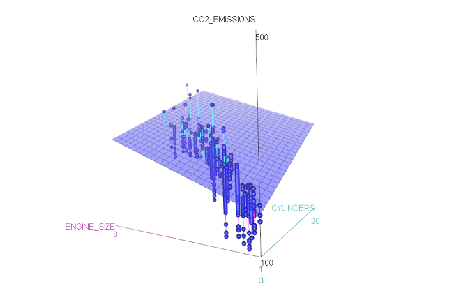

## Multiple Linear Regression

- Model response as *linear* function of *multiple* explanatory variables

\[y_i = \alpha + \beta_1 x_{1,i} + \beta_{2}x_{2,i} + \cdots + \epsilon_i\]

- Find parameters by minimizing squared errors (MSE)
- Linear functions represented by planes in 3D
  - Hyperplanes in higher dimensions

## Example

```r
library(broom)
lm( CO2_EMISSIONS ~ ENGINE_SIZE + CYLINDERS, data = fcr) %>% tidy()
## # A tibble: 3 x 5
##   term        estimate std.error statistic   p.value
##   <chr>          <dbl>     <dbl>     <dbl>     <dbl>
## 1 (Intercept)    122.       3.05     40.0  5.45e-214
## 2 ENGINE_SIZE     21.7      1.75     12.4  5.78e- 33
## 3 CYLINDERS       10.9      1.27      8.58 3.45e- 17
```

- Interpretation (*main effects*):
  - For 1L engine increase, CO2 emission increase by 21.71133gr/km, *irrespective* of # of cylinders
  - For each extra cylinder, CO2 emission increase by 10.87955gr/km, *irrespective* of engine size

## Assessing Fit

- Check *residuals* VS *fitted values* (want no patterns)

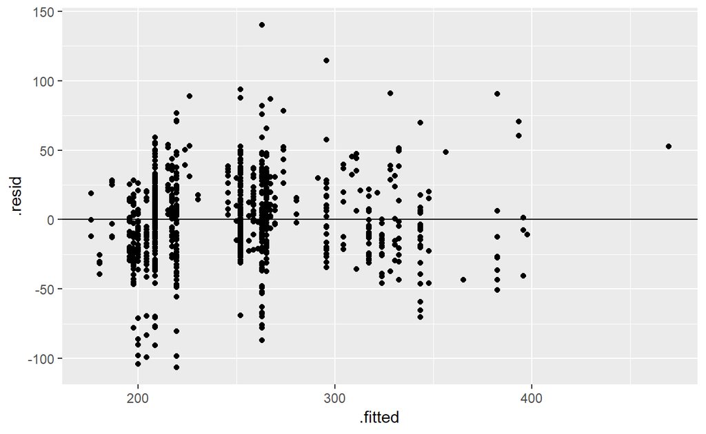

```r
lm_out %>% augment() %>% ggplot(aes(x = .fitted, y = .resid)) +
  geom_point() + geom_hline( yintercept = 0)
```

## Categorical Variables

- Include *categorical* variable in model
  - Fit separate *mean* for each category (similar to ANOVA)

```r
( lm_out = fcr %>% filter(MAKE %in%  c("FORD", "HONDA", "VOLKSWAGEN")) %>%
  lm( CO2_EMISSIONS ~ ENGINE_SIZE + MAKE - 1, data = .) ) %>% tidy()
## # A tibble: 4 x 5
##   term           estimate std.error statistic  p.value
##   <chr>             <dbl>     <dbl>     <dbl>    <dbl>
## 1 ENGINE_SIZE        33.9      2.04      16.6 3.21e-37
## 2 MAKEFORD          158.       6.94      22.7 7.25e-53
## 3 MAKEHONDA         121.       5.81      20.8 4.40e-48
## 4 MAKEVOLKSWAGEN    143.       6.91      20.7 8.76e-48
```

( `- 1` in model removes overall intercept )

## Example

- Parallel lines with different *intercepts*

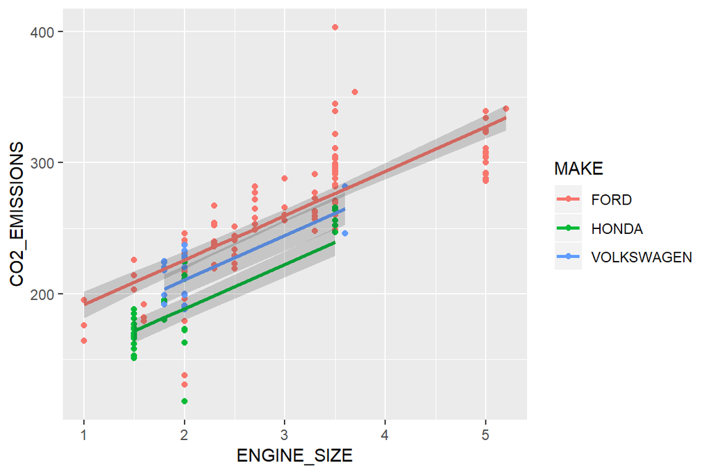

## Example

- Find *"greenest"* car manufacturer

```r
fcr %>% lm( CO2_EMISSIONS ~ ENGINE_SIZE + MAKE - 1, data = .) %>%
  tidy() %>% filter(str_detect(term, "MAKE")) %>%
  arrange(estimate) %>% slice( c(1:5) )
## # A tibble: 5 x 5
##   term         estimate std.error statistic   p.value
##   <chr>           <dbl>     <dbl>     <dbl>     <dbl>
## 1 MAKEMAZDA        117.      5.44      21.4 1.59e- 84
## 2 MAKEACURA        120.      8.92      13.5 3.75e- 38
## 3 MAKEHONDA        121.      4.54      26.7 8.30e-120
## 4 MAKELEXUS        123.      5.81      21.1 1.09e- 82
## 5 MAKECHRYSLER     124.      9.08      13.7 2.80e- 39
```

(Mazda is actually [most fuel-efficient automaker](https://www.autodeal.com.ph/articles/car-news-philippines/mazda-most-fuel-efficient-automaker-fifth-time))

## Intercept & Categorical Variables

- Intercept *replaces* mean of first category
  - Included by default in model
- Remaining categories represent *difference* in mean level

```r
fcr %>% filter(MAKE %in%  c("FORD", "HONDA", "VOLKSWAGEN")) %>%
lm( CO2_EMISSIONS ~ ENGINE_SIZE + MAKE, data = .) %>% tidy()
## # A tibble: 4 x 5
##   term           estimate std.error statistic  p.value
##   <chr>             <dbl>     <dbl>     <dbl>    <dbl>
## 1 (Intercept)       158.       6.94     22.7  7.25e-53
## 2 ENGINE_SIZE        33.9      2.04     16.6  3.21e-37
## 3 MAKEHONDA         -37.1      5.55     -6.69 3.29e-10
## 4 MAKEVOLKSWAGEN    -15.0      6.40     -2.35 1.99e- 2
```

## Dummy Variables

- Factors split into *dummy variables* taking 0/1 values

|  | factor | dummy_A | dummy_B | dummy_C | intercept |
| --- | --- | --- | --- | --- | --- |
| categ. A | "A" (1) | 1 | 0 | 0 | 1 |
| categ. B | "B" (2) | 0 | 1 | 0 | 1 |
| categ. C | "C" (3) | 0 | 0 | 1 | 1 |

- Categories represented by dummy variables in model \[ Y = \beta_A \cdot dum_A + \beta_B \cdot dum_B + \beta_C \cdot dum_C + \beta \cdot X + \ldots \Leftrightarrow \] \[ \Leftrightarrow Y = \alpha \cdot 1 + \beta_{\Delta B} \cdot dum_B + \beta_{\Delta C} \cdot dum_C + \beta \cdot X + \ldots\]

## Dummy Variables

- `fastDummies` package creates dummy variables

```r
library(fastDummies)
tibble( fct = c("A","B","A","C") ) %>%
  dummy_cols( select_columns = "fct" )
## # A tibble: 4 x 4
##   fct   fct_A fct_B fct_C
##   <chr> <int> <int> <int>
## 1 A         1     0     0
## 2 B         0     1     0
## 3 A         1     0     0
## 4 C         0     0     1
```

## Example

```r
fcr %>% filter(MAKE %in%  c("FORD", "HONDA", "VOLKSWAGEN")) %>%
  dummy_cols( "MAKE" )%>%
  lm( CO2_EMISSIONS ~ ENGINE_SIZE + MAKE_FORD + MAKE_HONDA +
        MAKE_VOLKSWAGEN -1, data = .) %>% tidy()
## # A tibble: 4 x 5
##   term            estimate std.error statistic  p.value
##   <chr>              <dbl>     <dbl>     <dbl>    <dbl>
## 1 ENGINE_SIZE         33.9      2.04      16.6 3.21e-37
## 2 MAKE_FORD          158.       6.94      22.7 7.25e-53
## 3 MAKE_HONDA         121.       5.81      20.8 4.40e-48
## 4 MAKE_VOLKSWAGEN    143.       6.91      20.7 8.76e-48
```

## Interactions

- Include *interaction effects* between variables (`X1 * X2`)
  - Allow *slopes* to change

```r
fcr %>% filter(MAKE %in%  c("FORD", "HONDA", "VOLKSWAGEN")) %>%
  lm( CO2_EMISSIONS ~ ENGINE_SIZE * MAKE, data = .) %>% tidy()
## # A tibble: 6 x 5
##   term                       estimate std.error statistic  p.value
##   <chr>                         <dbl>     <dbl>     <dbl>    <dbl>
## 1 (Intercept)                  161.        7.39   21.8    2.52e-50
## 2 ENGINE_SIZE                   32.9       2.19   15.1    1.01e-32
## 3 MAKEHONDA                    -58.5      15.1    -3.88   1.52e- 4
## 4 MAKEVOLKSWAGEN               -14.1      24.8    -0.569  5.70e- 1
## 5 ENGINE_SIZE:MAKEHONDA         10.4       6.81    1.53   1.27e- 1
## 6 ENGINE_SIZE:MAKEVOLKSWAGEN    -1.00     11.3    -0.0886 9.30e- 1
```

## Example

- Different lines (slope & intercept)

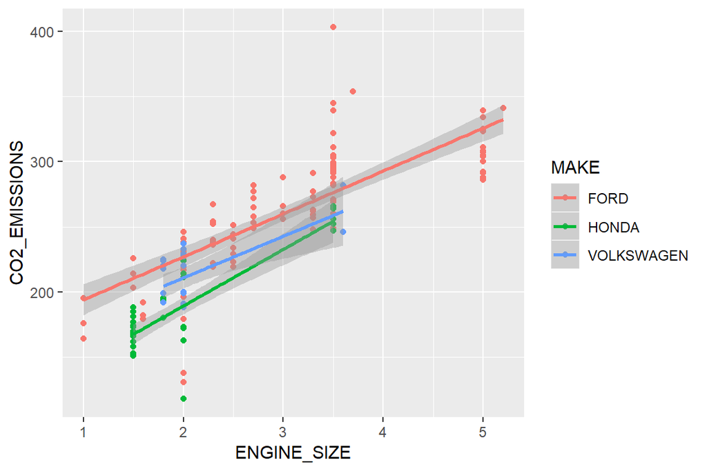

## Factor Variables

- `forcats` package for [working with factors](https://forcats.tidyverse.org/)
  - `fct_lump()`: collapse infrequent categories into "other"
  - `fct_relevel()`: reorder factor levels by hand
  - `fct_reorder()`: reorder factor by another variable
  - `fct_infreq()`: reorder factor by value frequency

```r
fcr %>% mutate(MAKE = fct_lump(MAKE, n = 3)) %>% head(3)
## # A tibble: 3 x 15
##    YEAR MAKE  MODEL CLASS ENGINE_SIZE CYLINDERS TRANSMISSION FUEL   CITY
##   <dbl> <fct> <chr> <chr>       <dbl>     <dbl> <chr>        <chr> <dbl>
## 1  2018 Other ILX   COMP~         2.4         4 AM8          Z       9.4
## 2  2018 Other MDX ~ SUV ~         3.5         6 AS9          Z      12.6
## 3  2018 Other MDX ~ SUV ~         3.5         6 AS9          Z      12.2
## # ... with 6 more variables: HWY <dbl>, COMB <dbl>, MPG <dbl>,
## #   CO2_EMISSIONS <dbl>, CO2_RATING <dbl>, SMOG_RATING <dbl>
```